# State-Space models in the mvgam package

```r
mvgam:::check_rhat(var_mod$model_output)
```

```
## Rhats above 1.05 found for 46 parameters
## *Diagnose further to investigate why the chains have not mixed
```

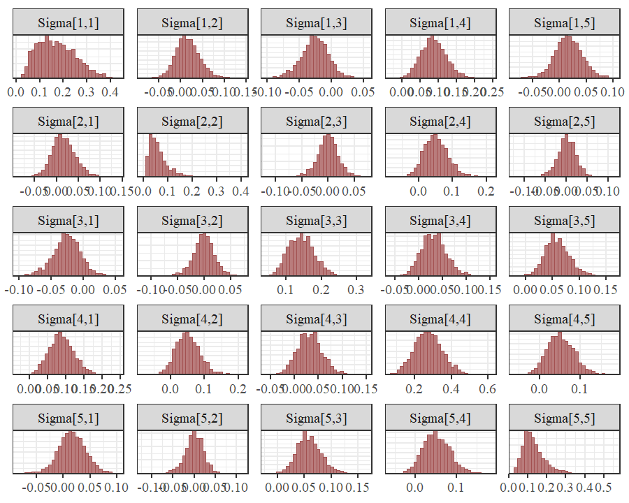

```r
Sigma_pars <- matrix(NA, nrow = 5, ncol = 5)
for(i in 1:5){
  for(j in 1:5){
    Sigma_pars[i, j] <- paste0('Sigma[', i, ',', j, ']')
  }
}
mcmc_plot(varcor_mod,
          variable = as.vector(t(Sigma_pars)),
          type = 'hist')
```

This symmetric matrix tells us there is support for correlated process errors. For example, series 1 and 3 (Bluegreens and Greens) show negatively correlated process errors, while series 1 and 4 (Bluegreens and Other.algae) show positively correlated errors. But it is easier to interpret these estimates if we convert the covariance matrix to a correlation matrix. Here we compute the posterior median process error correlations:

```r
Sigma_post <- as.matrix(varcor_mod, variable = 'Sigma', regex = TRUE)
median_correlations <- cov2cor(matrix(apply(Sigma_post, 2, median),
                                      nrow = 5, ncol = 5))
rownames(median_correlations) <-
  colnames(median_correlations) <-
  levels(plankton_train$series)

round(median_correlations, 2)
```

```
##             Bluegreens Diatoms Greens Other.algae Unicells
## Bluegreens        1.00    0.15  -0.17        0.41     0.11
## Diatoms           0.15    1.00  -0.01        0.42     0.01
## Greens           -0.17   -0.01   1.00        0.16     0.44
## Other.algae       0.41    0.42   0.16        1.00     0.28
## Unicells          0.11    0.01   0.44        0.28     1.00
```

Because this model is able to capture correlated errors, the VAR matrix has changed slightly:

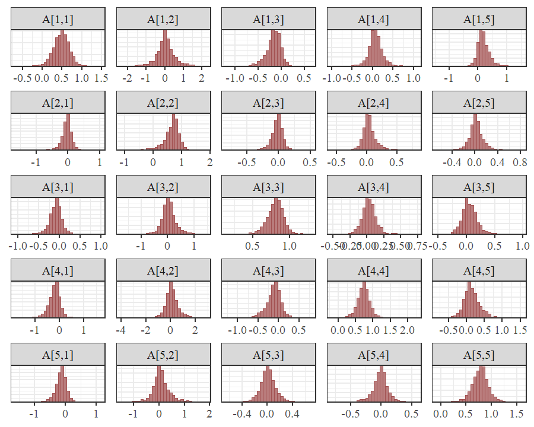

```r
A_pars <- matrix(NA, nrow = 5, ncol = 5)
for(i in 1:5){
  for(j in 1:5){
    A_pars[i, j] <- paste0('A[', i, ',', j, ']')
  }
}
mcmc_plot(varcor_mod,
          variable = as.vector(t(A_pars)),
          type = 'hist')
```

We still have some evidence of lagged cross-dependence, but some of these interactions have now been pulled more toward zero. But which model is better? Forecasts don’t appear to differ very much, at least qualitatively (here are forecasts for three of the series, for each model):

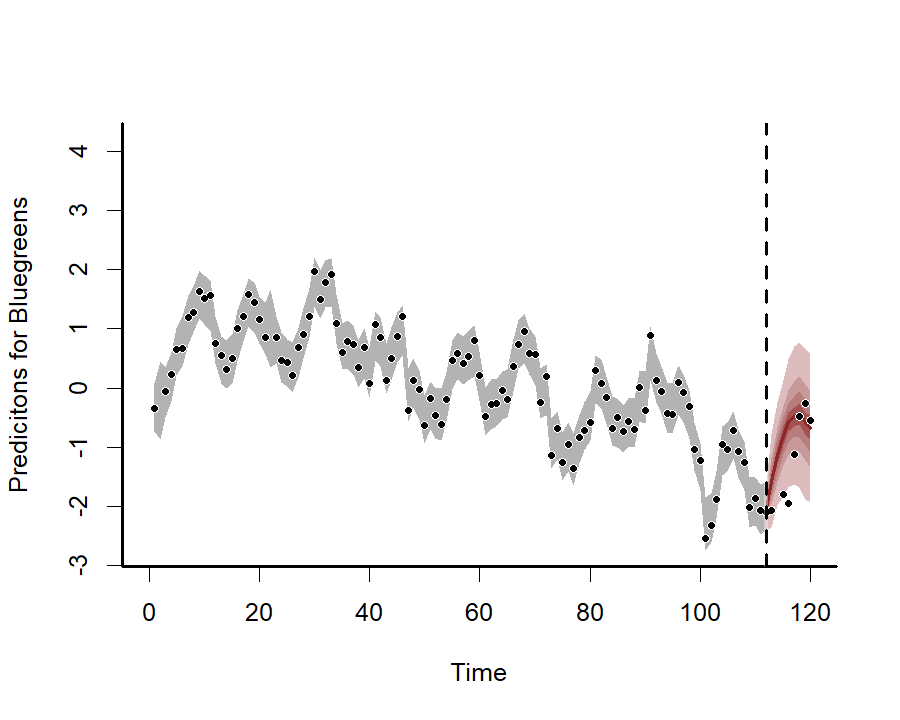

```
## Out of sample CRPS:
## [1] 2.948468
```

```r
plot(var_mod, type = 'forecast', series = 1, newdata = plankton_test)
```

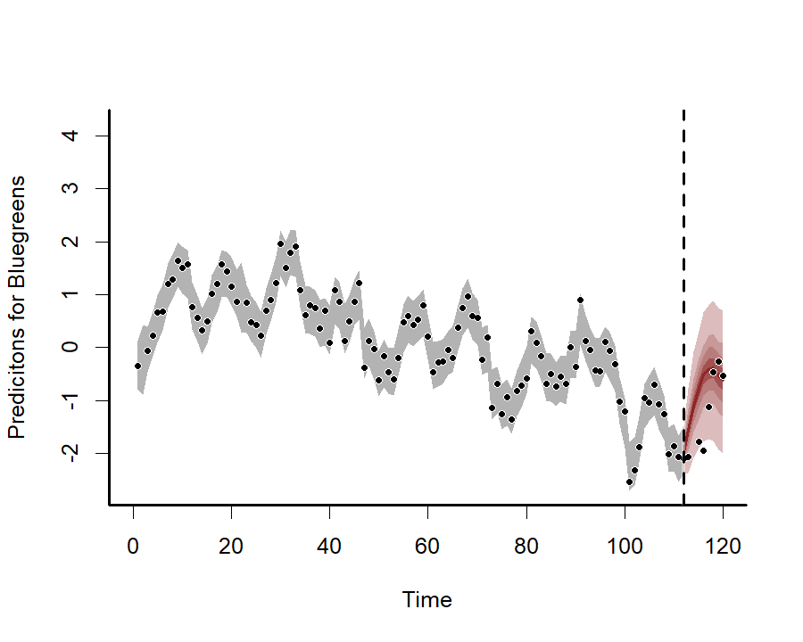

```
## Out of sample CRPS:
## [1] 3.004824
```

```r
plot(varcor_mod, type = 'forecast', series = 1, newdata = plankton_test)
```

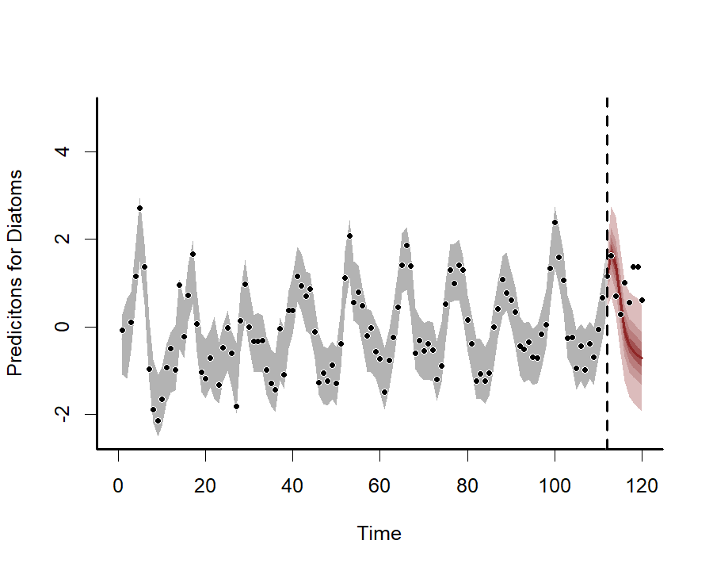

```
## Out of sample CRPS:
## [1] 6.161453
```

```r
plot(var_mod, type = 'forecast', series = 2, newdata = plankton_test)
```

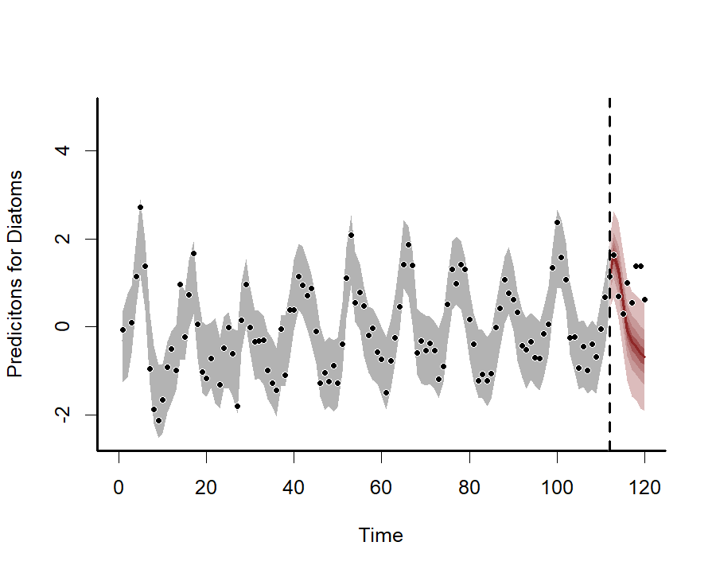

```
## Out of sample CRPS:
## [1] 5.898437
```

```r
plot(varcor_mod, type = 'forecast', series = 2, newdata = plankton_test)
```

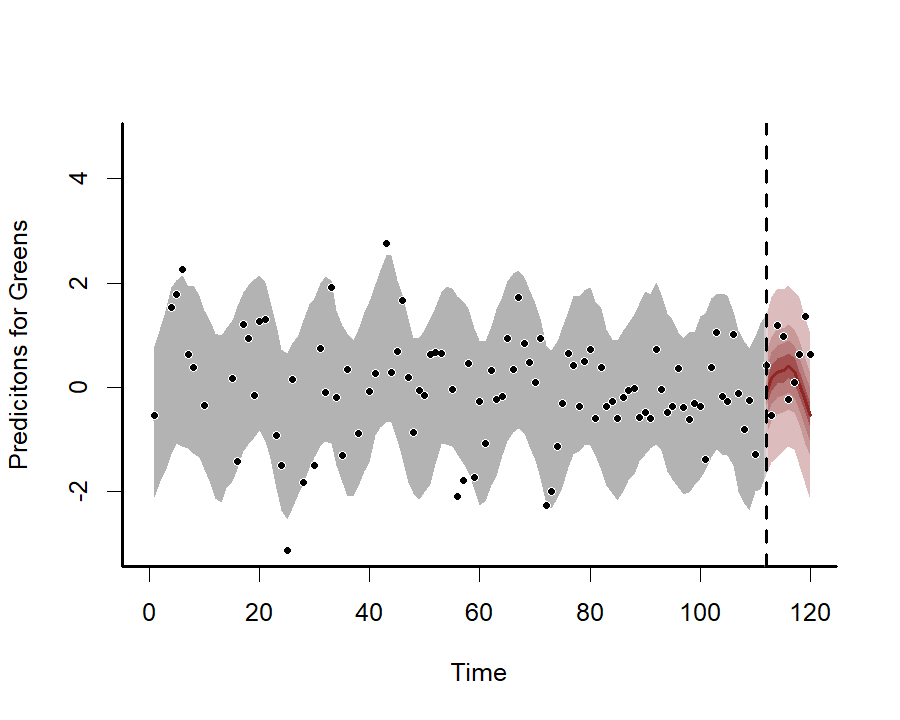

```
## Out of sample CRPS:
## [1] 4.182797
```

```r
plot(var_mod, type = 'forecast', series = 3, newdata = plankton_test)
```

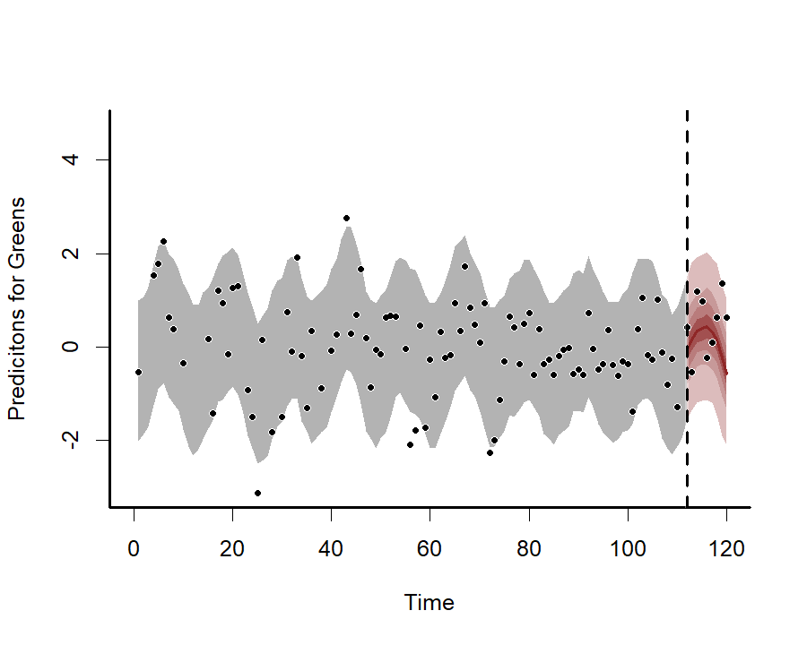

```
## Out of sample CRPS:
## [1] 4.07786
```

```r
plot(varcor_mod, type = 'forecast', series = 3, newdata = plankton_test)
```

We can compute the variogram score for out of sample forecasts to get a sense of which model does a better job of capturing the dependence structure in the true evaluation set:

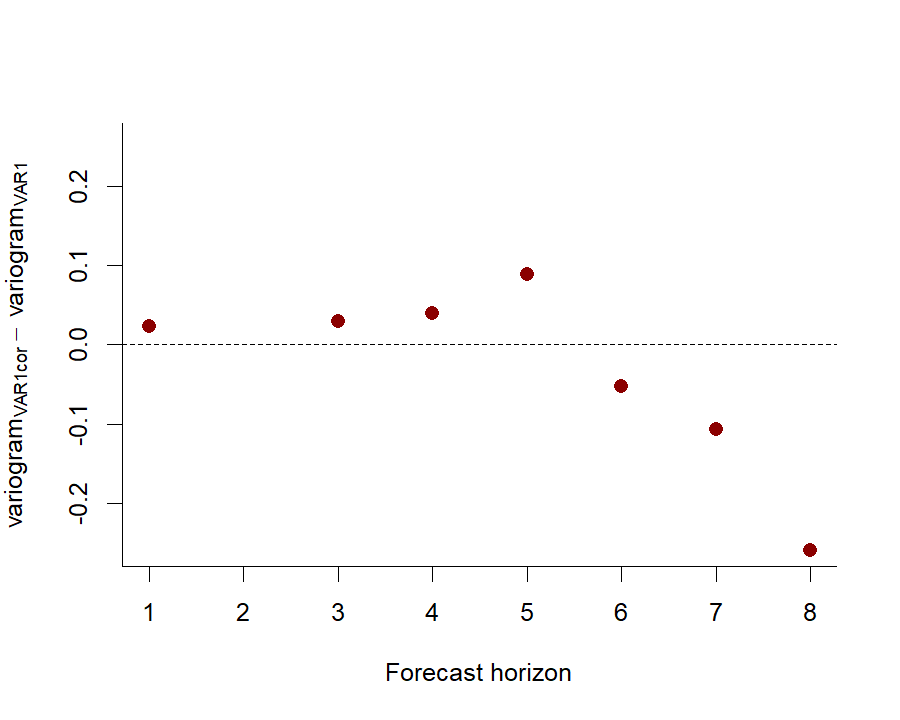

```r
# create forecast objects for each model
fcvar <- forecast(var_mod)
fcvarcor <- forecast(varcor_mod)

# plot the difference in variogram scores; a negative value means the VAR1cor model is better, while a positive value means the VAR1 model is better
diff_scores <- score(fcvarcor, score = 'variogram')$all_series$score -
  score(fcvar, score = 'variogram')$all_series$score
plot(diff_scores, pch = 16, cex = 1.25, col = 'darkred',
     ylim = c(-1*max(abs(diff_scores), na.rm = TRUE),
              max(abs(diff_scores), na.rm = TRUE)),
     bty = 'l',
     xlab = 'Forecast horizon',
     ylab = expression(variogram[VAR1cor]~-~variogram[VAR1]))
abline(h = 0, lty = 'dashed')
```

And we can also compute the energy score for out of sample forecasts to get a sense of which model provides forecasts that are better calibrated:

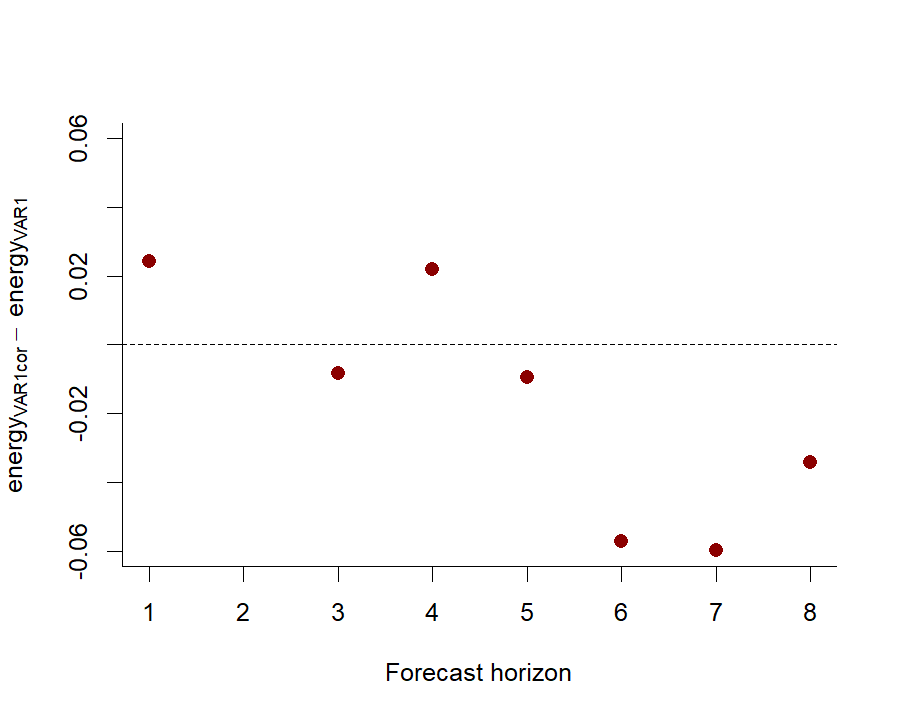

```r
# plot the difference in energy scores; a negative value means the VAR1cor model is better, while a positive value means the VAR1 model is better
diff_scores <- score(fcvarcor, score = 'energy')$all_series$score -
  score(fcvar, score = 'energy')$all_series$score
plot(diff_scores, pch = 16, cex = 1.25, col = 'darkred',
     ylim = c(-1*max(abs(diff_scores), na.rm = TRUE),
              max(abs(diff_scores), na.rm = TRUE)),
     bty = 'l',
     xlab = 'Forecast horizon',
     ylab = expression(energy[VAR1cor]~-~energy[VAR1]))
abline(h = 0, lty = 'dashed')
```

The models tend to provide similar forecasts, so we would probably need to use a more extensive rolling forecast evaluation exercise if we felt like we needed to only choose one for production. `mvgam` offers some utilities for doing this (i.e. see `?lfo_cv` for guidance).